# 🧠 O que são Graus de Liberdade?

Os graus de liberdade (GL) ou, em inglês, degrees of freedom (DoF), representam a quantidade de valores independentes que podem variar em um cálculo estatístico, respeitando uma ou mais restrições.

Em outras palavras: é o número de observações que podem variar livremente antes de uma estatística (como média ou soma) ficar determinada.

# 🧠 Quando os valores são independentes

Imagine que a média da população é conhecida (ex: altura média dos marcianos é 6). Cada valor que você coleta pode ser comparado com essa média de forma independente.

Ex: Se você coleta as alturas 8 e 5:

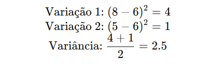

Nesse caso, os dois valores são independentes, e temos 2 graus de liberdade.

# 🎯 Exemplo Intuitivo

Mas prática, quase nunca conhecemos a média populacional, então usamos a média amostral estimada. Mas isso gera dependência entre os dados:

Se temos dois valores (5 e 8) e calculamos a média como (5 + 8 ) / 2 = 6.5. Então:

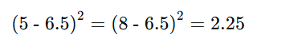

Aqui, sabendo um valor (ex: 5) e a média (6.5), o outro valor (8) fica determinado.

- ➡️ Os valores não são independentes.
- ➡️ Temos apenas 1 grau de liberdade.

# 📊 Exemplo em Python

Vamos calcular a variância de uma amostra com e sem ajuste de graus de liberdade.

```python
import numpy as np

# Exemplo: notas de 5 alunos
notas = np.array([7, 8, 6, 9, 10])

# Média da amostra
media = np.mean(notas)

# Variância com n no denominador (viésada)
variancia_viésada = np.var(notas, ddof=0)

# Variância com n - 1 no denominador (não viésada)
variancia_corrigida = np.var(notas, ddof=1)

print(f"🎯 Média: {media}")
print(f"⚠️ Variância com GL = 5 (viésada): {variancia_viésada:.2f}")
print(f"✅ Variância com GL = 4 (corrigida): {variancia_corrigida:.2f}")
```

```
🎯 Média: 8.0
⚠️ Variância com GL = 5 (viésada): 2.00
✅ Variância com GL = 4 (corrigida): 2.50
```

# 📉 Por que usamos 𝑛 − 1 e não n?

Para valores independentes: NÃO há subtração de 1 no grau de liberdade. Se todos os dados são totalmente independentes entre si — ou seja, nenhum parâmetro foi estimado a partir deles — então o grau de liberdade é igual ao número total de observações.

Já quandoo estimamos parâmetros com os dados dependentes, cada parâmetro estimado reduz o número de graus de liberdade.

Fórmula: df = 𝑁 − 𝑘

Onde:

- N = número de observações
- k = número de parâmetros estimados (ex: média, inclinação na regressão, etc.)

Moral da história: Graus de liberdade representam a quantidade de variação legítima e livre nos dados.Quanto mais parâmetros você estima a partir dos dados, menos liberdade os dados têm para variar independentemente.

# 🔍 Em que situações os GL aparecem?

- Testes t: O número de graus de liberdade define qual distribuição t usar.
- Intervalos de confiança: Usamos GL para determinar o valor crítico.
- ANOVA: Separa GL entre "entre grupos" e "dentro dos grupos".
- Regressão: Cada coeficiente ajustado consome 1 grau de liberdade.

# 📝 Conclusão

- Graus de liberdade indicam quantos valores são livres para variar após aplicar restrições.
- São fundamentais para estimativas corretas de variância e testes de hipóteses.
- Quanto mais restrições, menos graus de liberdade.
- Usamos n−1 para ajustar a variância e evitar subestimar a variabilidade real.